# Boxplot

The boxplot is a visual representation of the distribution of a numeric variable. The box component is bound by the first and third quartiles (Q1 and Q3) while the median is represented by a line drawn through the box.

At either end of the box are the whiskers, which represent the extremities of the data. Specifically these are the highest and lowest values in the data set that are not considered outliers.

#### Outliers

In boxplots, any observation less than *Q1-1.5IQR* or greater than *Q3+1.5IQR* is considered an outlier. (Recall the *IQR=Q3-Q1*). Outliers are indicated separately to the boxplot.

#### Syntax

The command used to construct a boxplot is simply `boxplot`, specifying the name of the variable. You can also compare multiple groups by additionally specifying a grouping variable (i.e. some categorical variable in the data).

- `boxplot(numericvariable)`
- `boxplot(numericvariable ~ groupingvariable)`

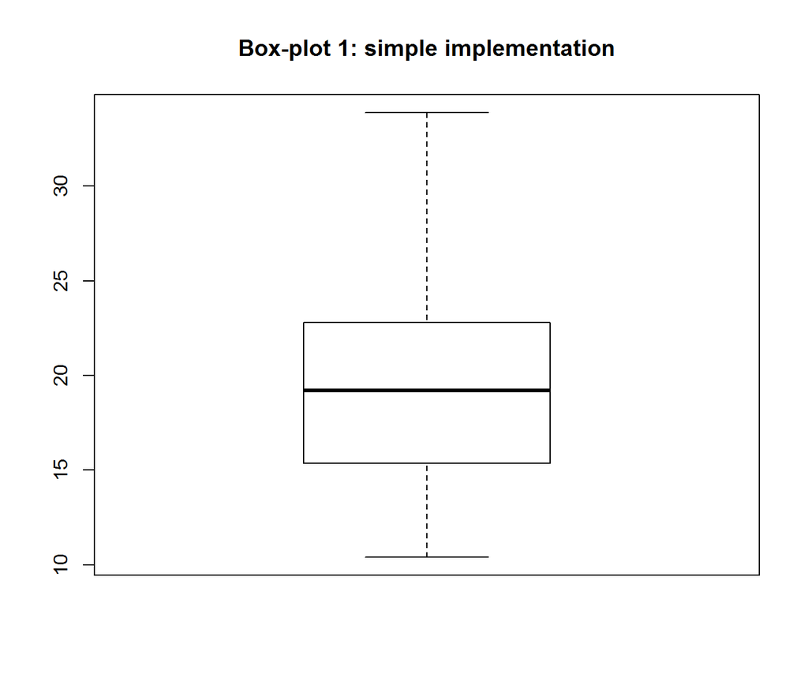

```r
attach(mtcars)

#### Box plot 1
boxplot(mpg)
title("Box-plot 1: simple implementation")
```

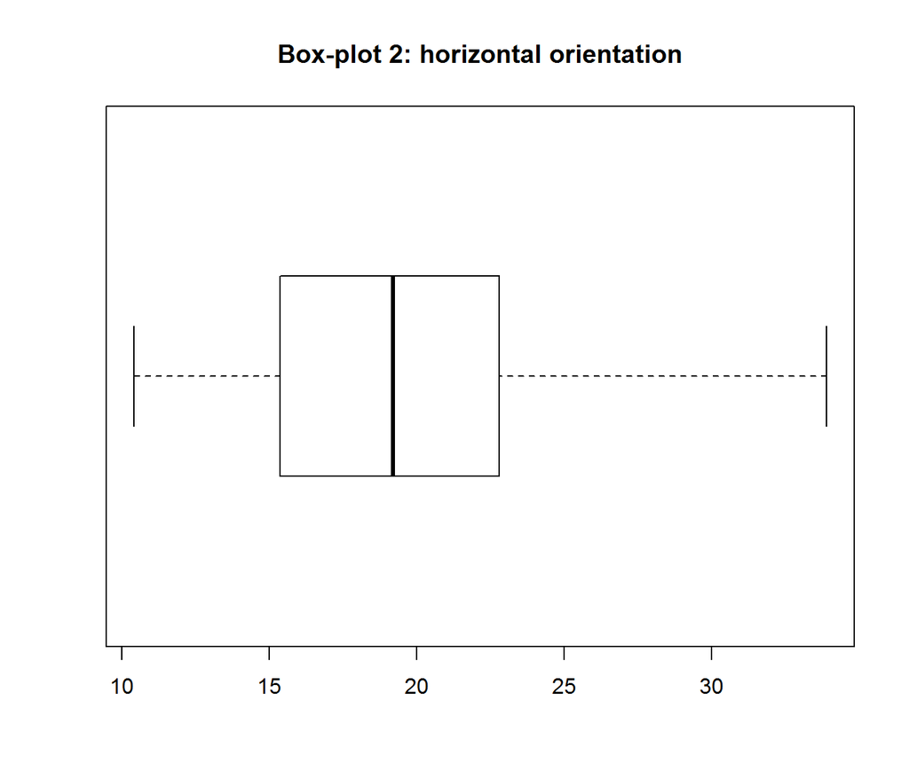

```r
#### Box plot 2
boxplot(mpg,horizontal=TRUE)
title("Box-plot 2: horizontal orientation")
```

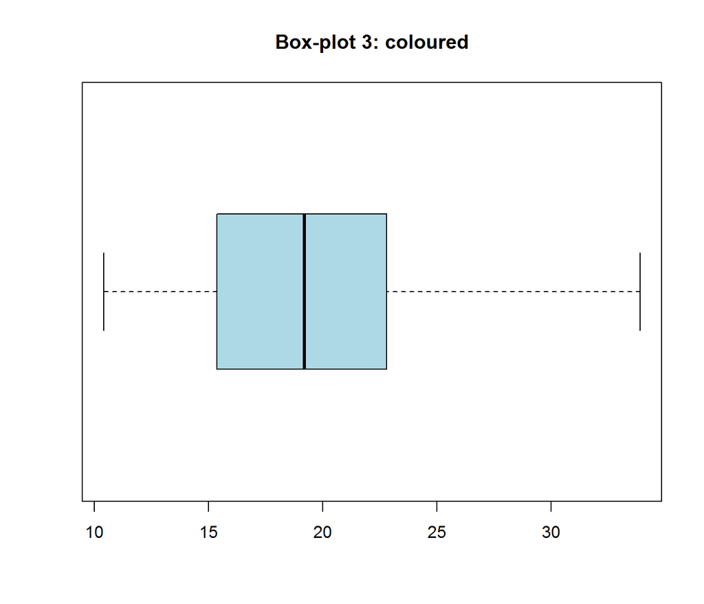

```r
#### Box plot 3
boxplot(mpg,horizontal=TRUE,col="lightblue")
title("Box-plot 3: coloured")
```

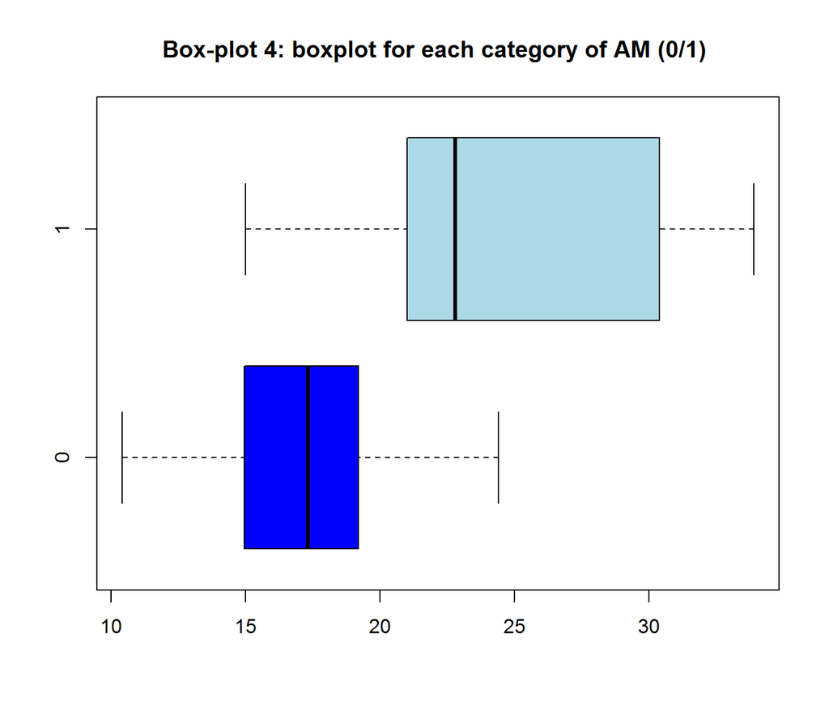

```r
#### Box plot 4
boxplot(mpg ~ am, horizontal=TRUE,col=c("blue","lightblue"))
title("Box-plot 4: boxplot for each category of AM (0/1) ")
```

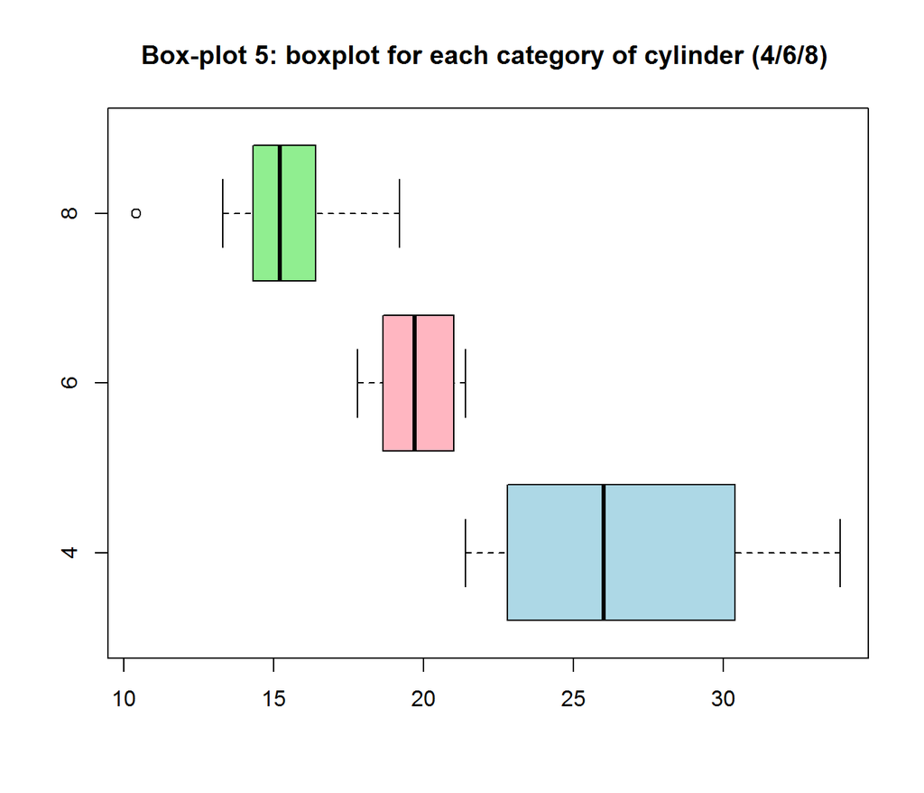

```r
#### Box plot 5
boxplot(mpg ~ cyl, horizontal=TRUE,col=c("lightblue","lightpink","lightgreen"))
title("Box-plot 5: boxplot for each category of cylinder (4/6/8) ")
```

```r
detach(mtcars)
```

#### Some useful commands

- `pch` used to specify the plot character (Recommend using 16, 17 and 18)
- `cex` used to specify plot character size (default value is 1)